# Prosper Loan Data Exploration by Aloke K Das

# Multivariate Analysis

#### Talk about some of the relationships you observed in this part of the investigation. Were there features that strengthened each other in terms of looking at your feature(s) of interest?

The loan distribution pattern over the creadit scores remain pretty much the same over the years. This is the same as I see for the loan distribution over the income range for all the years. The higher income bracket consistently borrowed larger loans for all the years. I would have liked to see more prominent trend for the BorrowerAPR for various terms, though.

#### Were there any interesting or surprising interactions between features?

The classification of the loans into two different classes, however, was an interesting way to analyze the dataset. some characteristics are distincly different for the borrowers who completed the loans vs. those who defaulted. I wish I could leverage this classification strategy more to be able to predict the outcome of the loan. Maybe the next Machine Learning course will be helpful towards that direction.

# Final Plots and Summary

#### Plot One

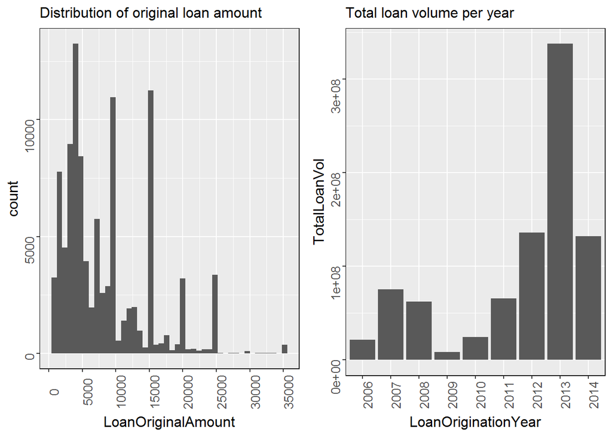

### Description One

This company primarily issues small loans around or below $25000. Surely, it focused on this segment of the market for small borrowers for non-residential personal loans. In general, we see a positive upward trend in the business procured by Prosper over the years. However, the 2014 data may be incomplete and collected only for part of the year.

### Plot Two

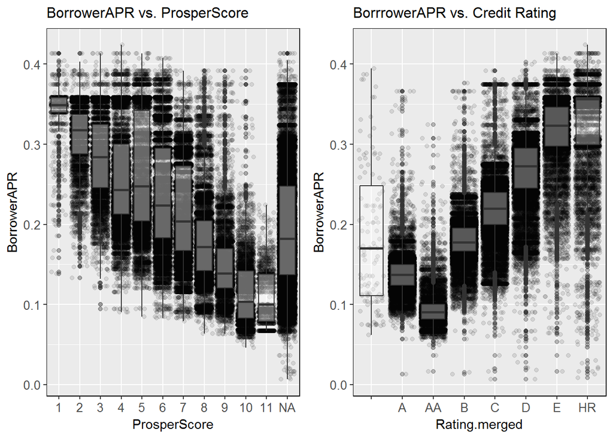

### Description Two

In this section I tried to understand any relationship between the the BorrowerAPR and the remaining variables. I could find the strongest correlation with the ProsperScore. However, I understand that the prosperScore itself is an outcome variable for this company which is based on their proprietary mathematical formulation of variables. I have tried to plot several graphs to display how the APR varies. I could see a definitive trend as is evident in the graph that plots the Credit rating.

### Plot Three

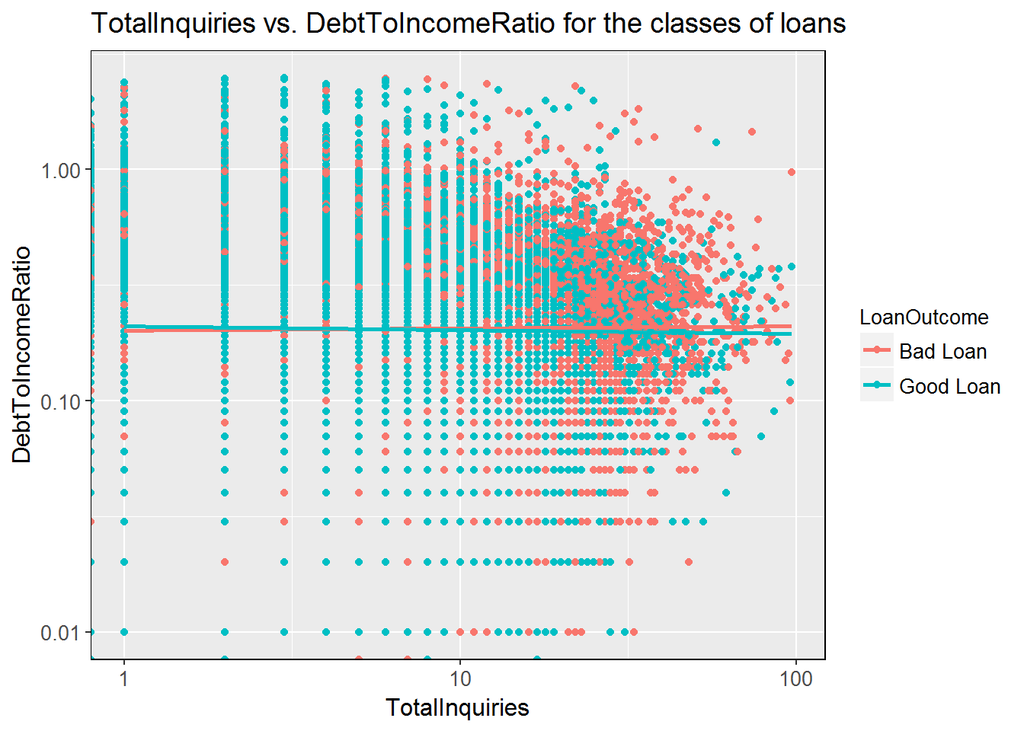

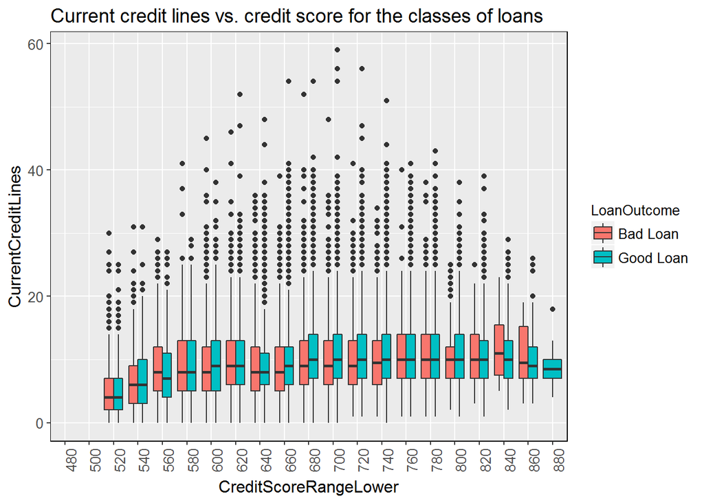

### Description Three

I wanted to work with the two classes of loans - good and bad. Although I could not find a definitive relationship of the outcome of the loan (good/bad), I wanted to go ahead and explore some characteristics of the variables as they are displayed for these two classes of loans.

The first plot shows a tendency of the bad loan borrowers to have more enquiries than the good loan borrowers. The DTI also tends to be more for such borrowers. The second plot shows the the bad loan borrowers are carrying comparable current credit lines with the good loan borrowers having the same credit scores.

These two plots show some expected tendencies that match our intuition. I am sure these variables will have a place in the formula that can predict the outcome of the loan.

# Reflection

This loan dataset posed a great opportunity to audit the data in multiple dimensions. A few correlations were somewhat obvious, e.g. APR vs. term of the loan, or, the credit score. However, there were many more that surfaced only after some exploration.

The loan volume is usually small for this peer-to-peer lending company. The APR is usually high for such loans and even higher for the longest term which is 36 months. I eliminated a few outliers from the dataset.

It was not an easy project for me to complete. I struggled to decide which relations are good to showcase and explore. I kept of plotting various variables and looked to find out some patterns. I picked up two goals - determining BorrowerAPR and the ultimate outcome (defaulted/completed) of the loan. I have presented the correlations/trends in this submission. However, I am certainly looking forward to the next Machine Learning course where I am expecting to carry this project further and learn the techniques to predict the outcome of the loan.